# describe_wings

Jacob Idec

2023-03-23

## Q1: How is each response variable distributed and correlated?

```
## [1] "black"
##    Min. 1st Qu.  Median    Mean 3rd Qu.    Max.
## 0.00000 0.00000 0.00000 0.03753 0.01062 0.89820
```

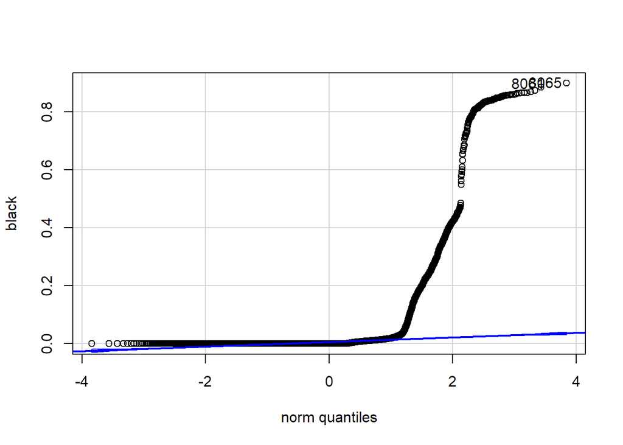

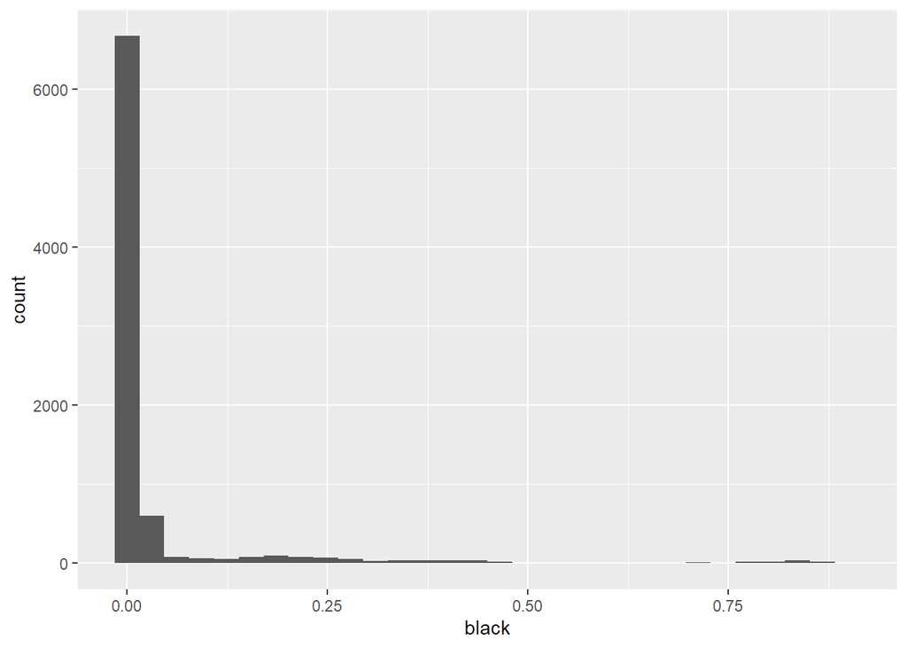

```
## [1] ""
## [1] "brown"
##     Min.  1st Qu.   Median     Mean  3rd Qu.     Max.
## 0.000000 0.006911 0.016083 0.036577 0.027755 0.884144
```

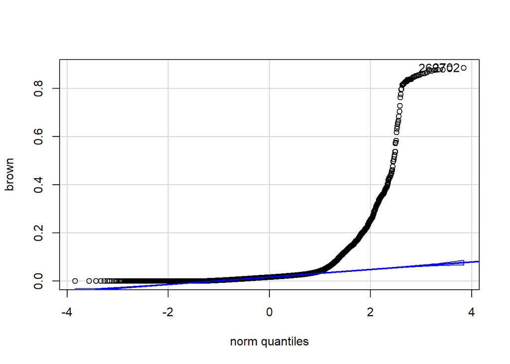

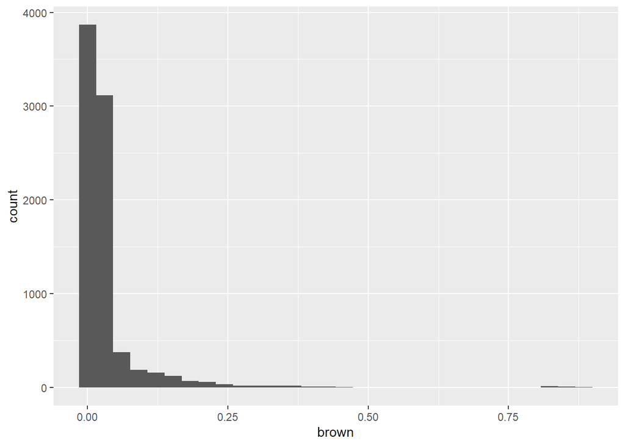

```
## [1] ""
## [1] "yellow"
##     Min.  1st Qu.   Median     Mean  3rd Qu.     Max.
## 0.000000 0.003257 0.008479 0.057153 0.024693 0.930385
```

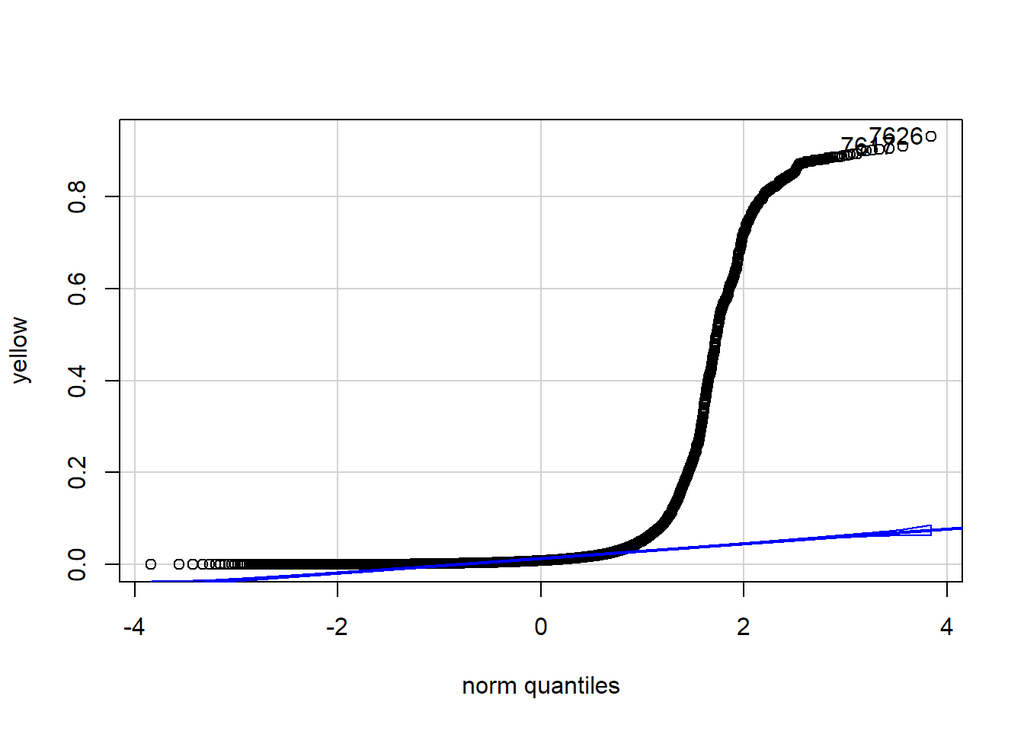

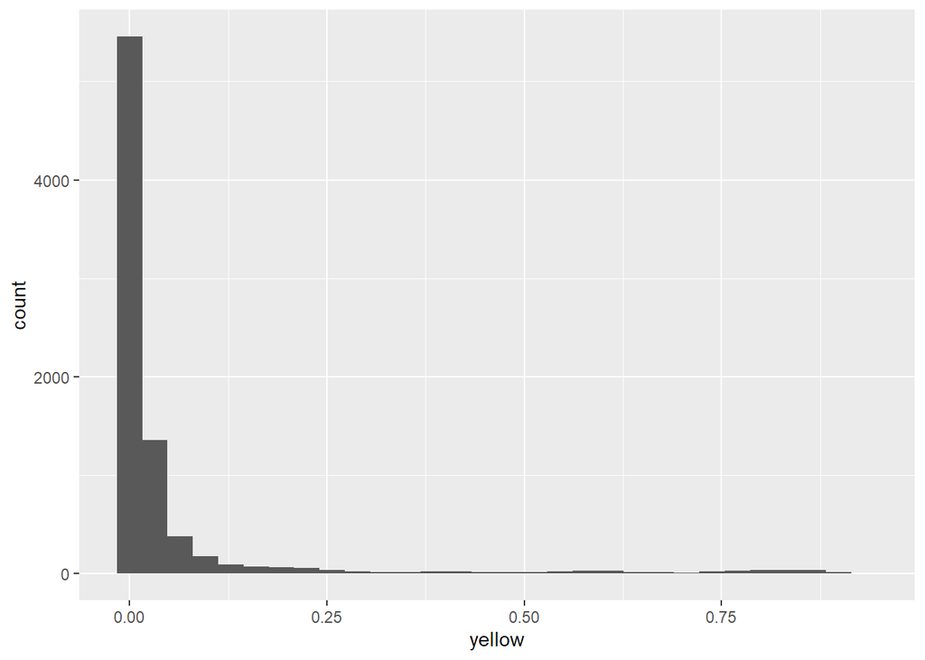

```
## [1] ""
## [1] "PC1_foreall"
##    Min. 1st Qu.  Median    Mean 3rd Qu.    Max.    NA's
##  -6.161  -5.742  -4.551   0.480  -1.817  74.670    7230
```

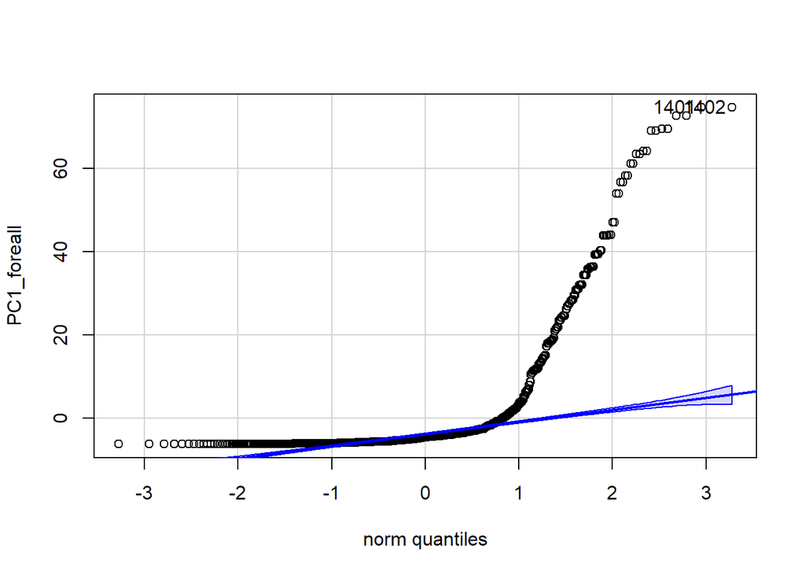

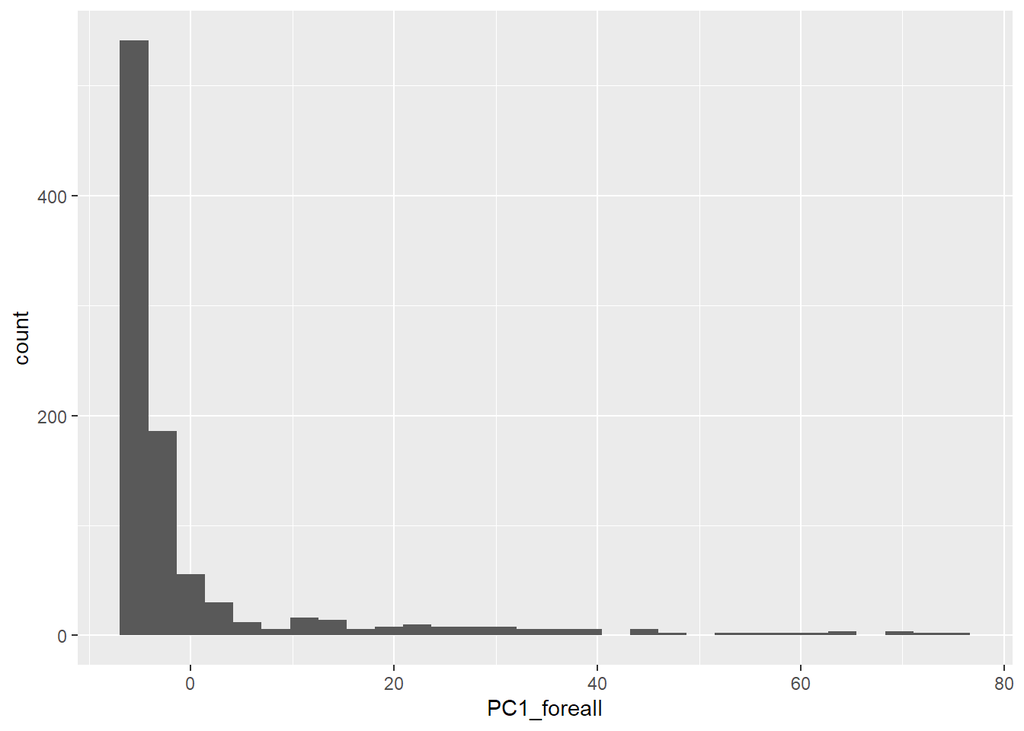

```
## [1] ""
## [1] "PC2_foreall"
##    Min. 1st Qu.  Median    Mean 3rd Qu.    Max.    NA's
## -35.805  -1.940  -1.187   0.119   1.109  28.426    7230
```

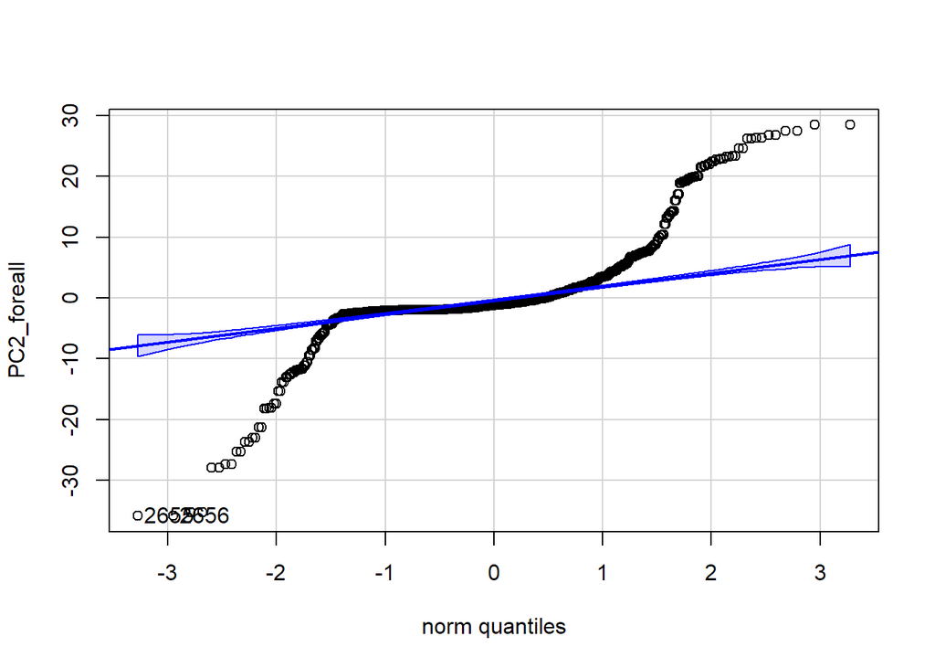

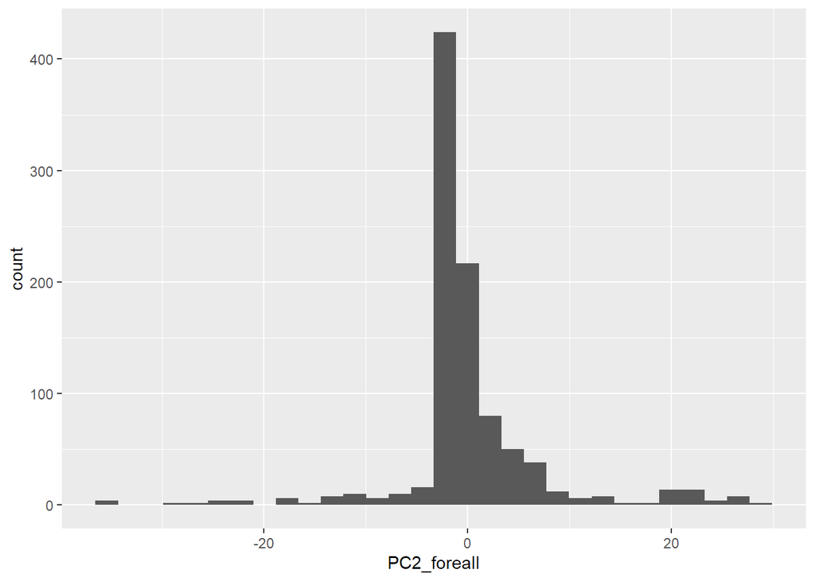

```
## [1] ""
## [1] "PC1_hindall"
##    Min. 1st Qu.  Median    Mean 3rd Qu.    Max.    NA's
##  -3.676  -3.277  -2.864   0.369  -1.781  59.519    7230
```

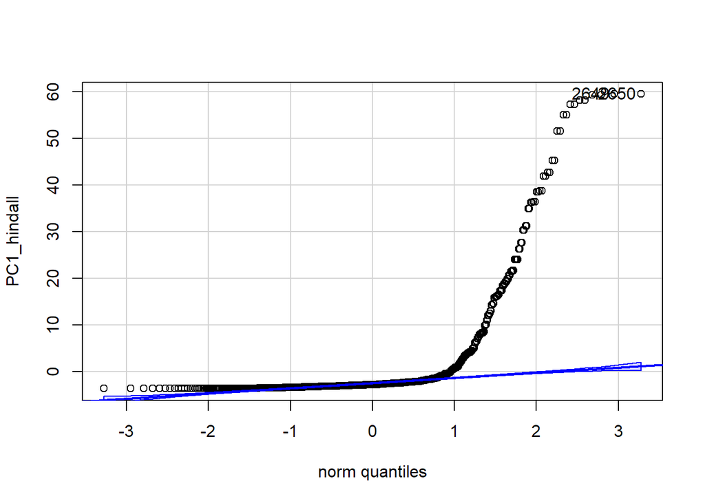

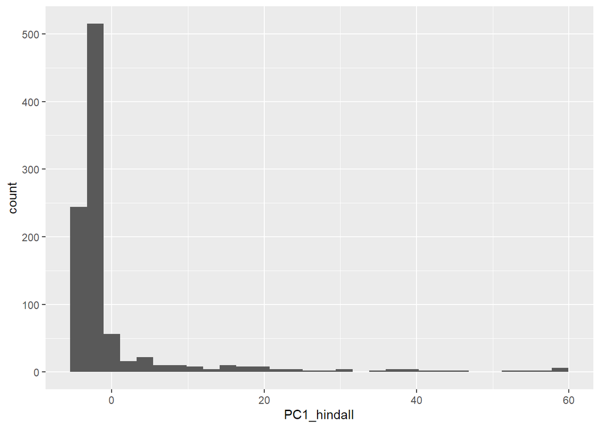

```
## [1] ""
## [1] "PC2_hindall"
##    Min. 1st Qu.  Median    Mean 3rd Qu.    Max.    NA's
## -22.098  -2.715  -0.255   0.051   1.540  16.838    7230
```

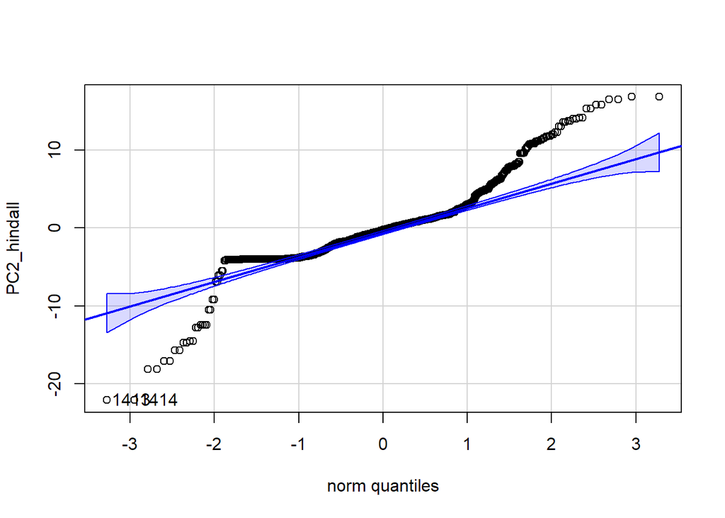

```
## [1] ""
```

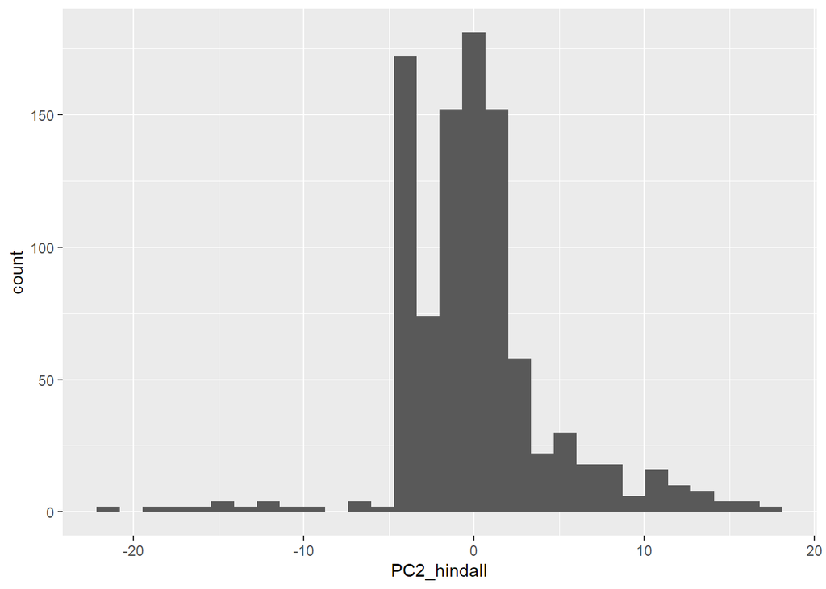

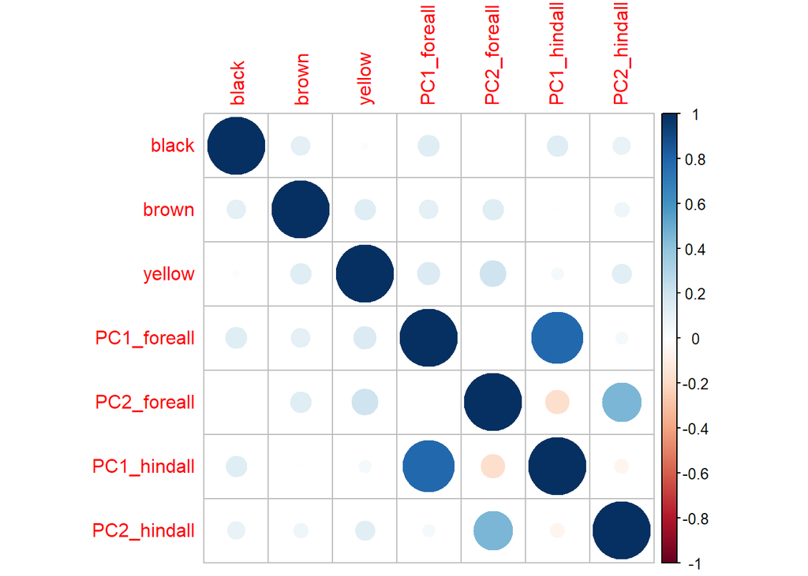

Amounts of pigments are not normally distributed at all - a small number of dragonfly species have all the pigment, while most have none or almost none

Few have a large percent of black-pigmented area, but many have a little bit (pterostigma or nodus!)

The 2nd PCs of the hind and forewing are more normally distributed than the 1st PCs - the average 2nd PC value is more like an average dragonfly

Black and yellow are both slightly (0.13) correlated with brown

The PC1 for fore and hind wings are very strongly correlated and the PC2s are correlated as well

## Q2: How is each predictor variable distributed and correlated?

```
## [1] "Sex"
```

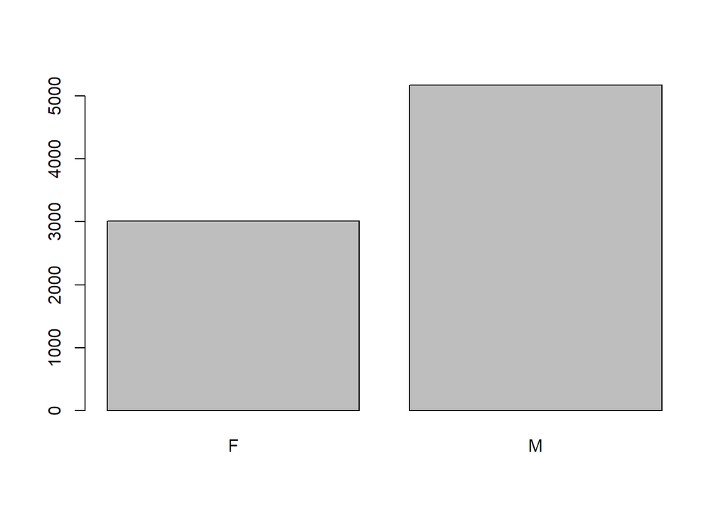

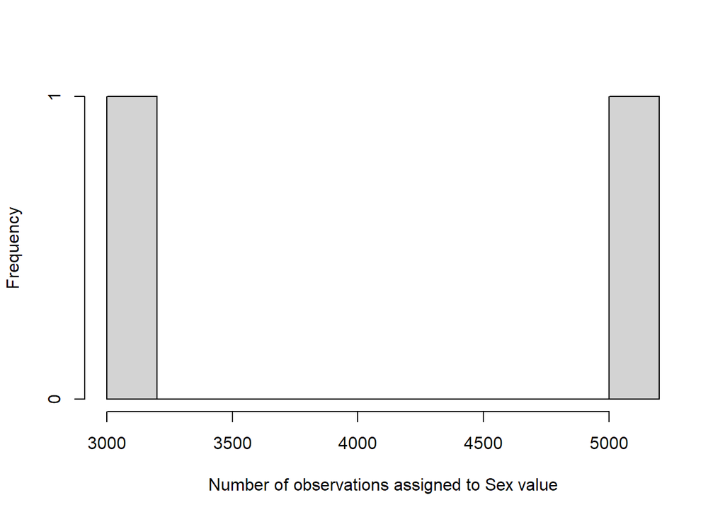

```
## [1] "Percent of values with 3 or less observations: 0"
## [1] ""
## [1] "flight_type"
```

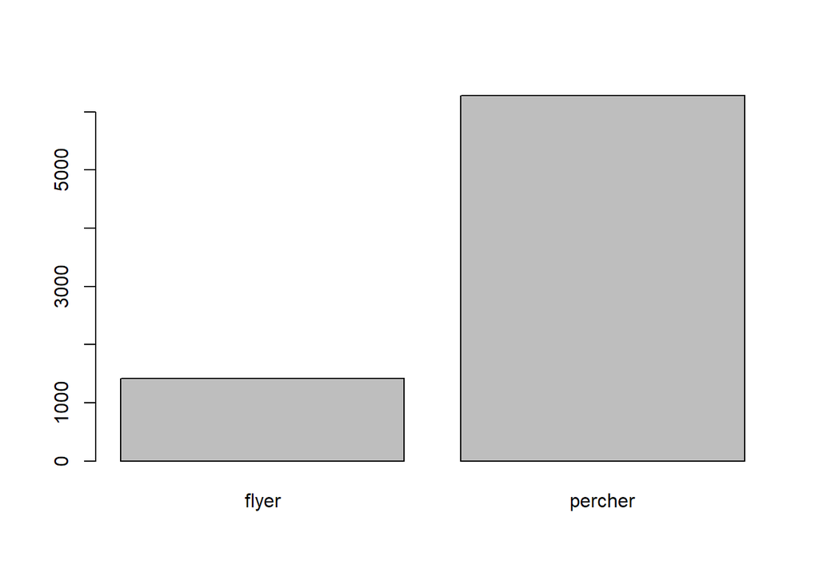

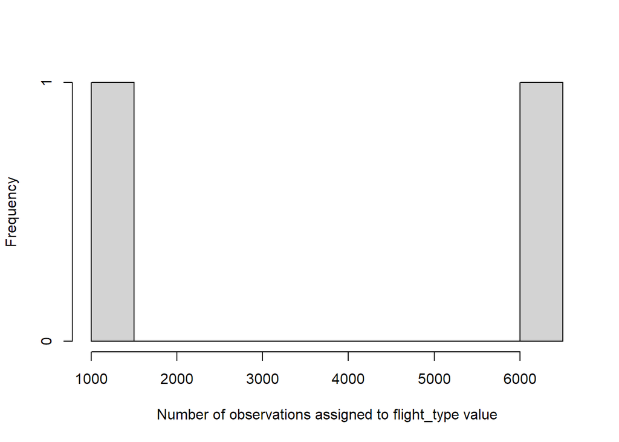

```
## [1] "Percent of values with 3 or less observations: 0"
## [1] ""
## [1] "species"
```

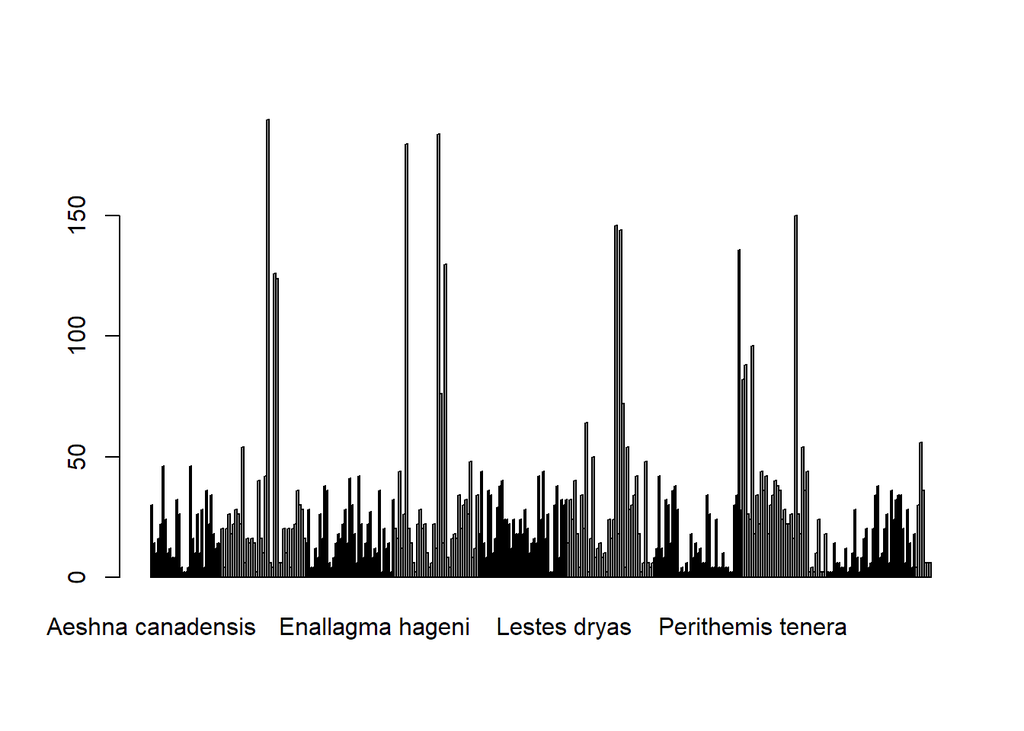

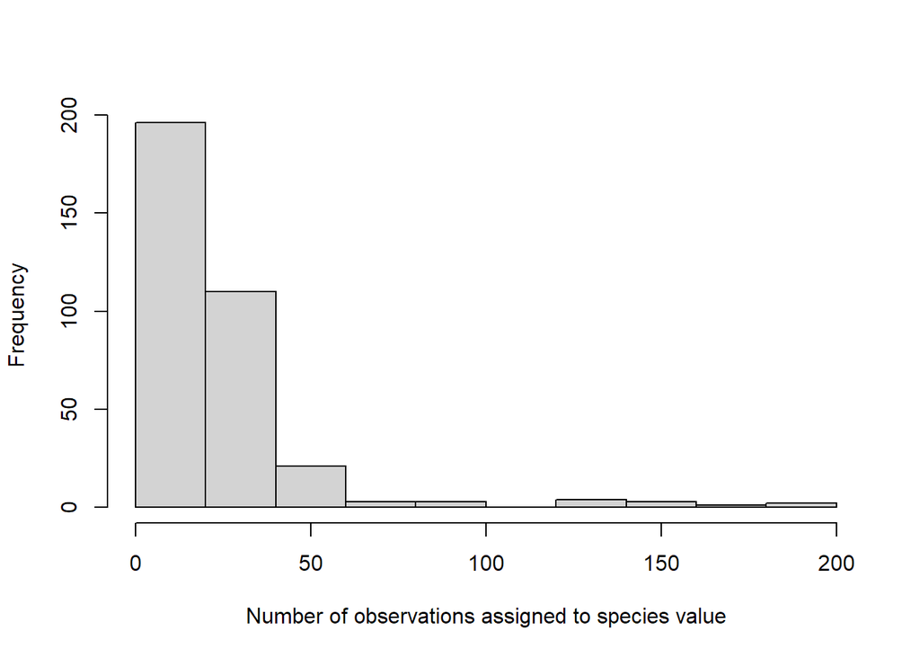

```
## [1] "Percent of values with 3 or less observations: 0.0728862973760933"
## [1] ""
## [1] "Family"
```

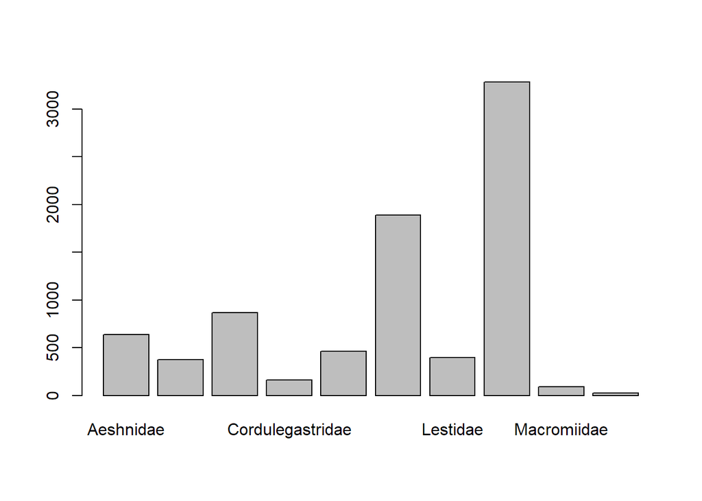

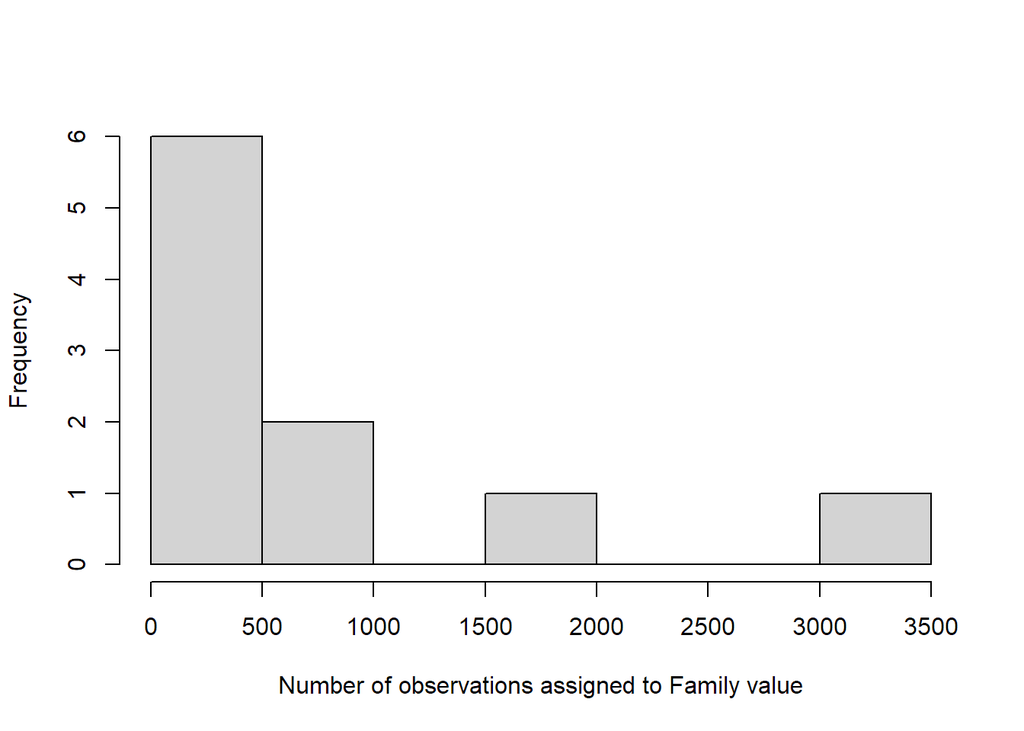

```
## [1] "Percent of values with 3 or less observations: 0"
## [1] ""
## [1] "Country"
```

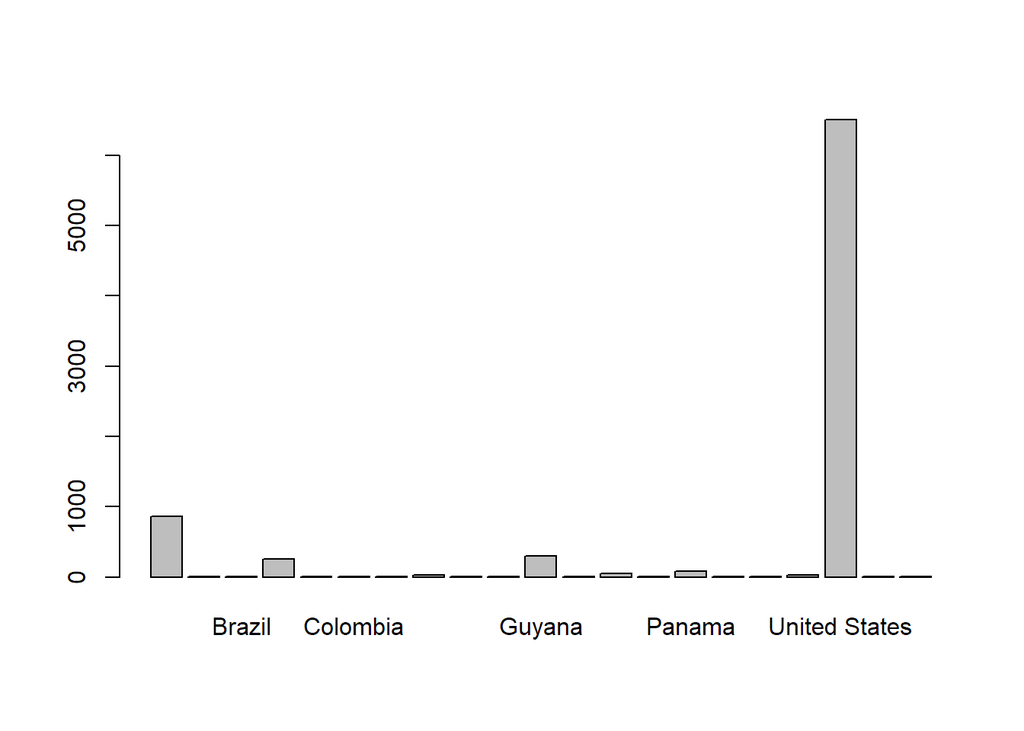

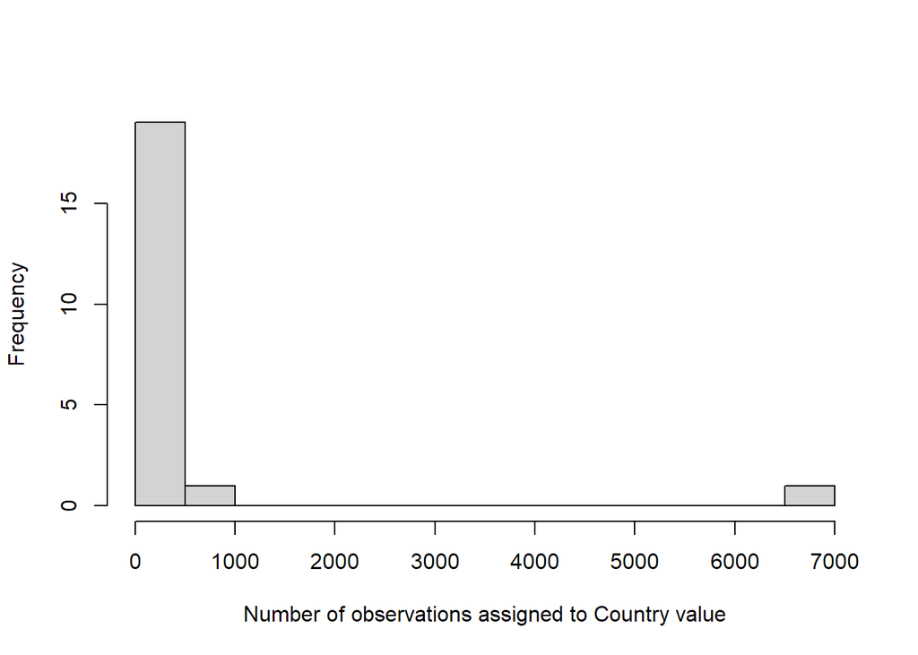

```
## [1] "Percent of values with 3 or less observations: 0.19047619047619"
## [1] ""
## [1] "wing_type"
```

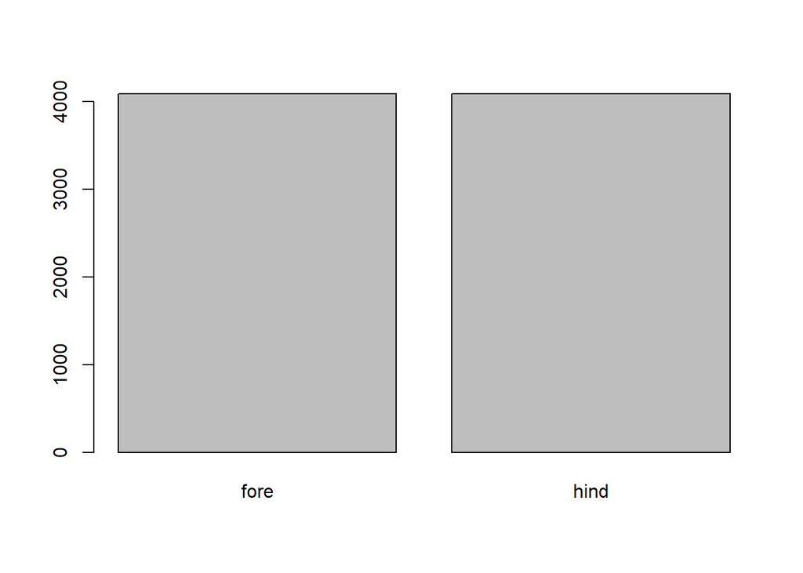

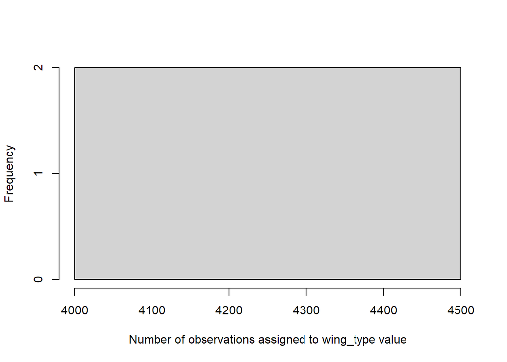

```
## [1] "Percent of values with 3 or less observations: 0"
## [1] ""
```

```
## [1] "temp_indv"
##    Min. 1st Qu.  Median    Mean 3rd Qu.    Max.    NA's
##    19.0    90.0   142.0   138.4   194.0   236.0    2170
```

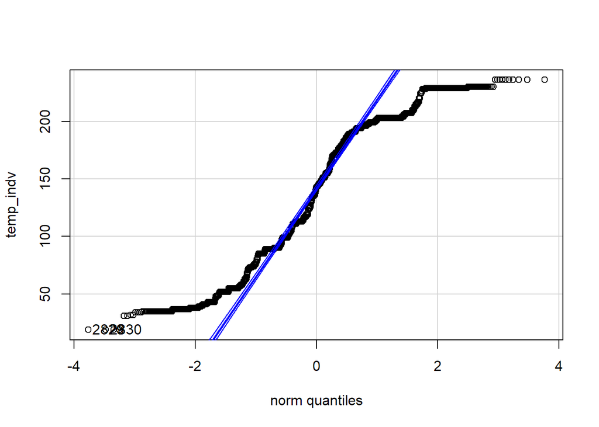

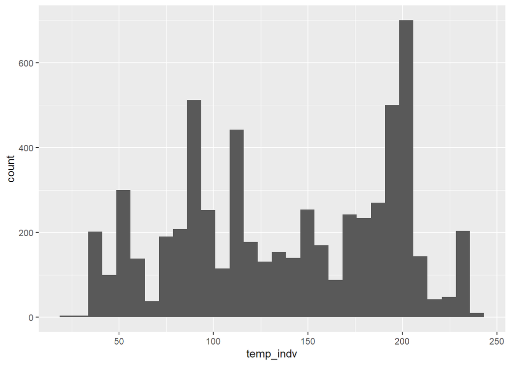

```
## [1] ""
## [1] "prec_indv"
##    Min. 1st Qu.  Median    Mean 3rd Qu.    Max.    NA's
##      94     783    1130    1010    1269    2157    2170
```

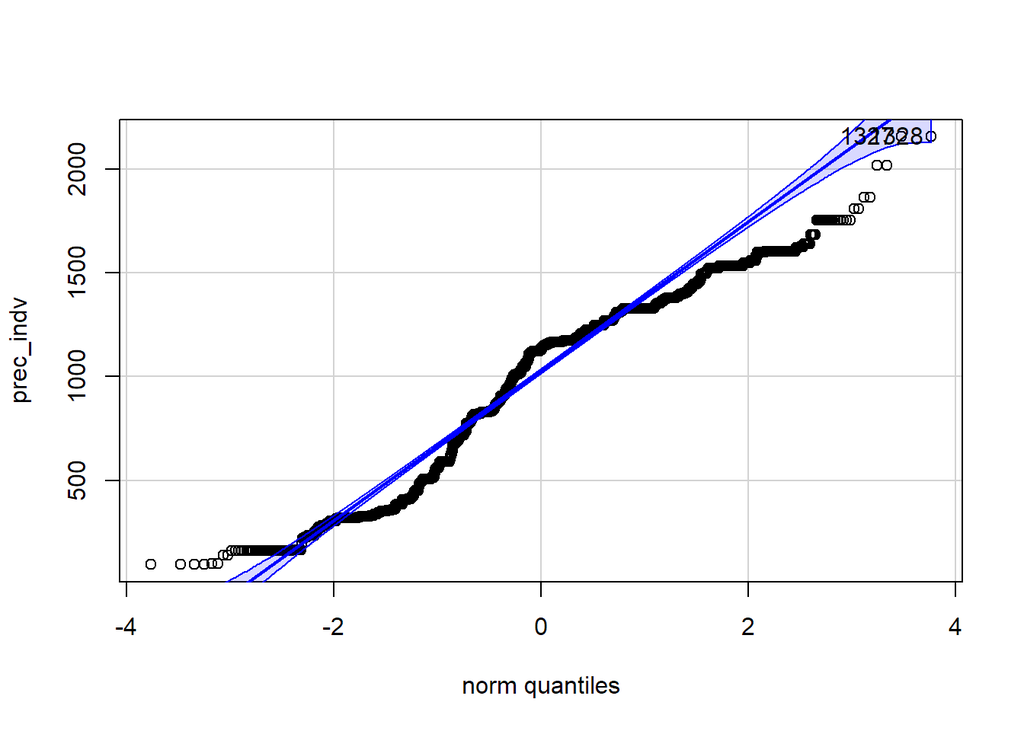

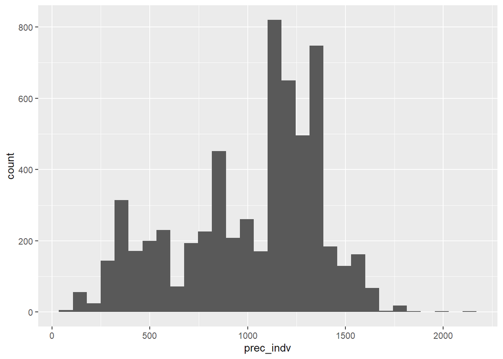

```
## [1] ""
## [1] "se_indv"
##    Min. 1st Qu.  Median    Mean 3rd Qu.    Max.    NA's
##    3348    6549    7923    7773    8856   12560    2170
```

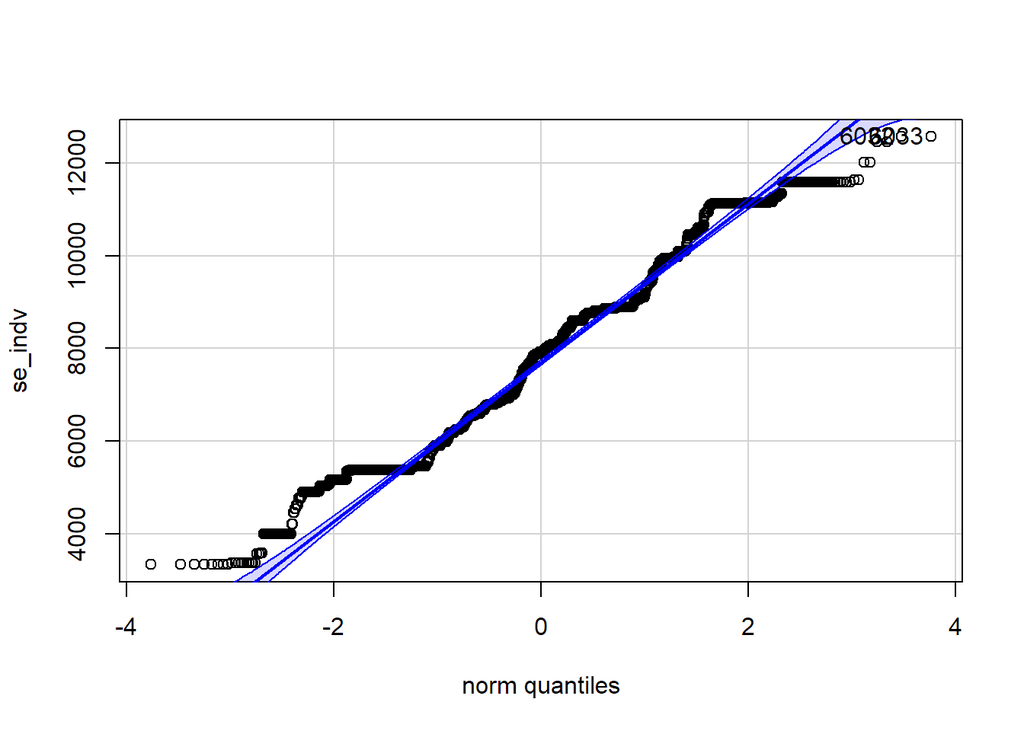